# Dublin Data Science Workshop on Bootstrap Methods

### 1.1.2 Bootstrapping Standard Deviation, $\sigma$

Bootstrapping works for any statistic, not just the mean, so let us try this out. Estimates of higher-order moments and extremal measures are more sensitive to sample noise, so we expect these estimates to be wider.

#### 1.1.2.1 Sample Size $N = 10$

```r
boot_10_sd_tbl <- F_stdnorm_10_tbl %>%
  pull(x) %>%
  construct_bootstrap_size_plots(sd)

boot_10_sd_tbl %>%
  group_by(btstrp_size) %>%
  summarise(summ = list(summary(btstrp_val))) %>%
  unnest_wider(summ)
```

```
## # A tibble: 4 x 7
##   btstrp_size  Min. `1st Qu.` Median  Mean `3rd Qu.`  Max.
##         <dbl> <dbl>     <dbl>  <dbl> <dbl>     <dbl> <dbl>
## 1         100 0.363     0.693  0.794 0.784     0.888  1.09
## 2         500 0.279     0.700  0.802 0.788     0.898  1.13
## 3        1000 0.279     0.696  0.795 0.783     0.886  1.14
## 4       10000 0.156     0.693  0.791 0.780     0.881  1.23
```

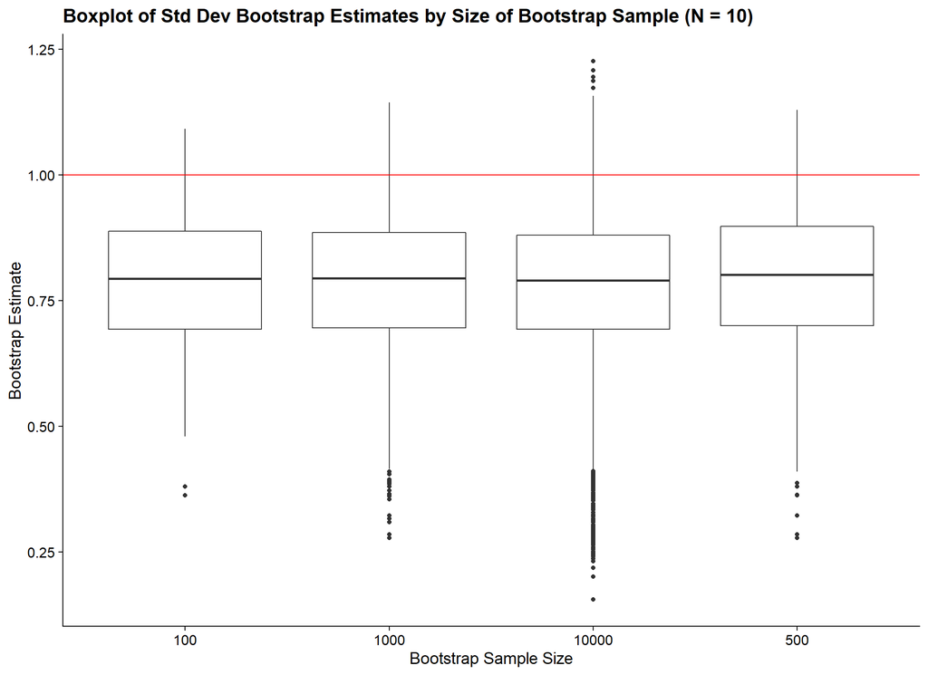

```r
ggplot(boot_10_sd_tbl) +
  geom_boxplot(aes(x = vec_cast(btstrp_size, character()), y = btstrp_val)) +
  geom_hline(aes(yintercept = 1), colour = 'red') +
  xlab("Bootstrap Sample Size") +
  ylab("Bootstrap Estimate") +
  ggtitle("Boxplot of Std Dev Bootstrap Estimates by Size of Bootstrap Sample (N = 10)")
```

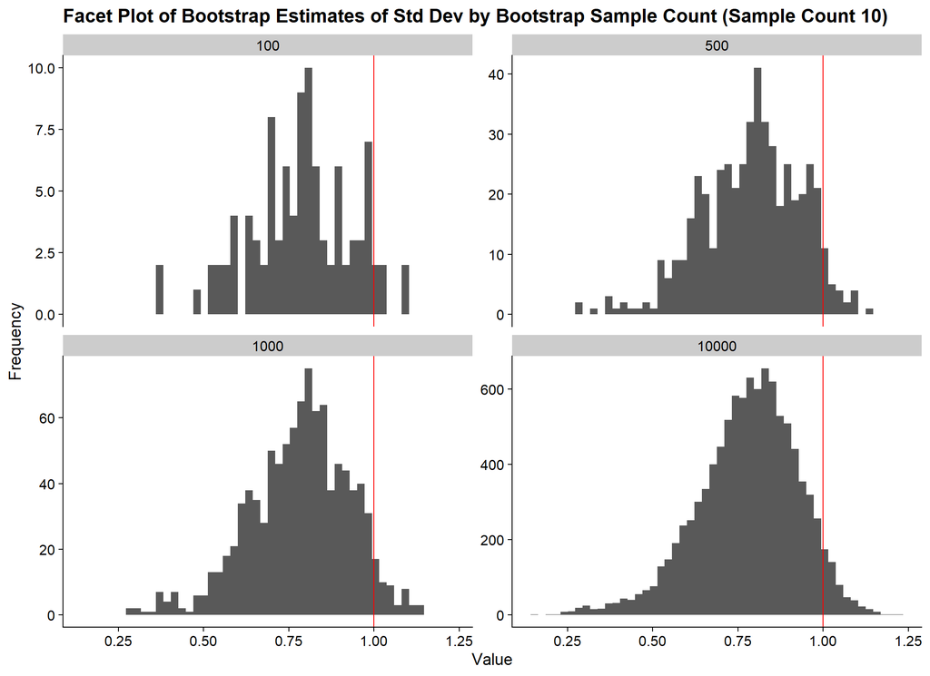

```r
ggplot(boot_10_sd_tbl) +
  geom_histogram(aes(x = btstrp_val), bins = 50) +
  geom_vline(aes(xintercept = 1), colour = 'red') +
  facet_wrap(vars(btstrp_size), scales = 'free_y') +
  xlab("Value") +
  ylab("Frequency") +
  ggtitle("Facet Plot of Bootstrap Estimates of Std Dev by Bootstrap Sample Count (Sample Count 10)")
```

#### 1.1.2.2 Sample Size $N = 100$

```r
boot_100_sd_tbl <- F_stdnorm_100_tbl %>%
  pull(x) %>%
  construct_bootstrap_size_plots(sd)

boot_100_sd_tbl %>%
  group_by(btstrp_size) %>%
  summarise(summ = list(summary(btstrp_val))) %>%
  unnest_wider(summ)
```

```
## # A tibble: 4 x 7
##   btstrp_size  Min. `1st Qu.` Median  Mean `3rd Qu.`  Max.
##         <dbl> <dbl>     <dbl>  <dbl> <dbl>     <dbl> <dbl>
## 1         100 0.744     0.982   1.02  1.03      1.07  1.21
## 2         500 0.744     0.984   1.03  1.04      1.09  1.25
## 3        1000 0.744     0.983   1.03  1.03      1.09  1.32
## 4       10000 0.744     0.980   1.03  1.03      1.09  1.33
```

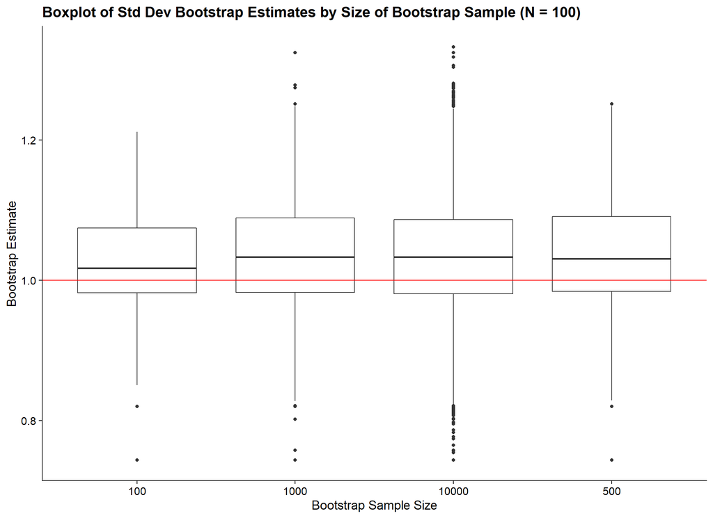

```r
ggplot(boot_100_sd_tbl) +
  geom_boxplot(aes(x = vec_cast(btstrp_size, character()), y = btstrp_val)) +
  geom_hline(aes(yintercept = 1), colour = 'red') +
  xlab("Bootstrap Sample Size") +
  ylab("Bootstrap Estimate") +
  ggtitle("Boxplot of Std Dev Bootstrap Estimates by Size of Bootstrap Sample (N = 100)")
```

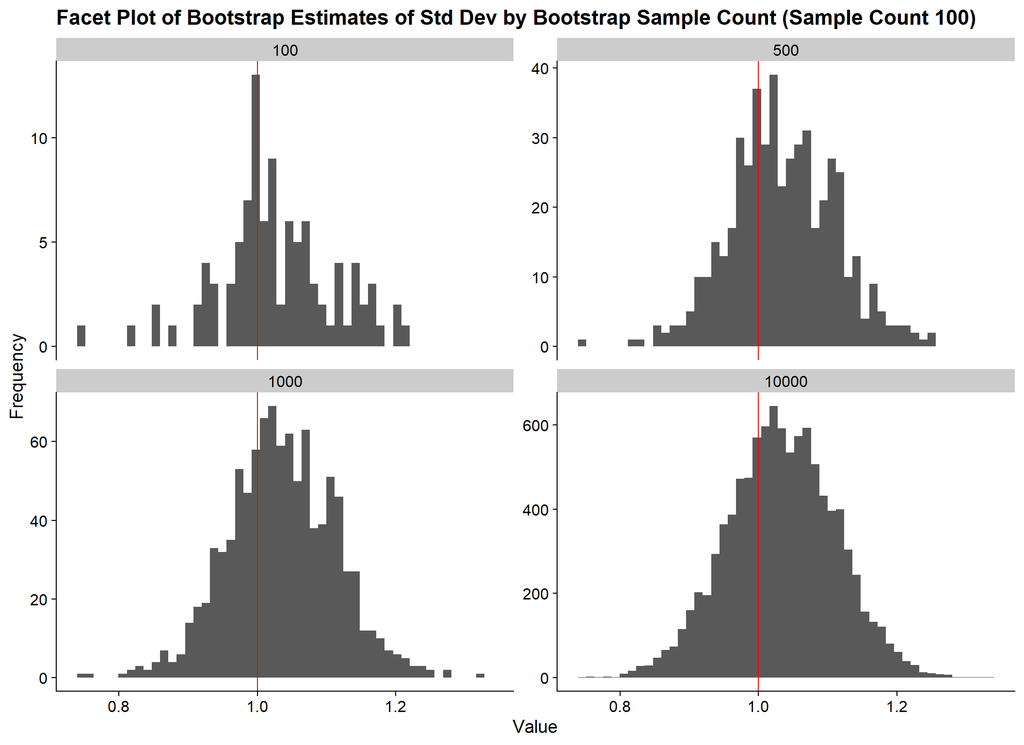

```r
ggplot(boot_100_sd_tbl) +
  geom_histogram(aes(x = btstrp_val), bins = 50) +
  geom_vline(aes(xintercept = 1), colour = 'red') +
  facet_wrap(vars(btstrp_size), scales = 'free_y') +
  xlab("Value") +
  ylab("Frequency") +
  ggtitle("Facet Plot of Bootstrap Estimates of Std Dev by Bootstrap Sample Count (Sample Count 100)")
```

#### 1.1.2.3 Sample Size $N = 1,000$

```r
boot_1000_sd_tbl <- F_stdnorm_1000_tbl %>%
  pull(x) %>%
  construct_bootstrap_size_plots(sd)

boot_1000_sd_tbl %>%
  group_by(btstrp_size) %>%
  summarise(summ = list(summary(btstrp_val))) %>%
  unnest_wider(summ)
```

```
## # A tibble: 4 x 7
##   btstrp_size  Min. `1st Qu.` Median  Mean `3rd Qu.`  Max.
##         <dbl> <dbl>     <dbl>  <dbl> <dbl>     <dbl> <dbl>
## 1         100 0.938     0.986   1.00  1.00      1.02  1.05
## 2         500 0.916     0.987   1.00  1.00      1.02  1.07
## 3        1000 0.916     0.986   1.00  1.00      1.02  1.07
## 4       10000 0.916     0.986   1.00  1.00      1.02  1.09
```

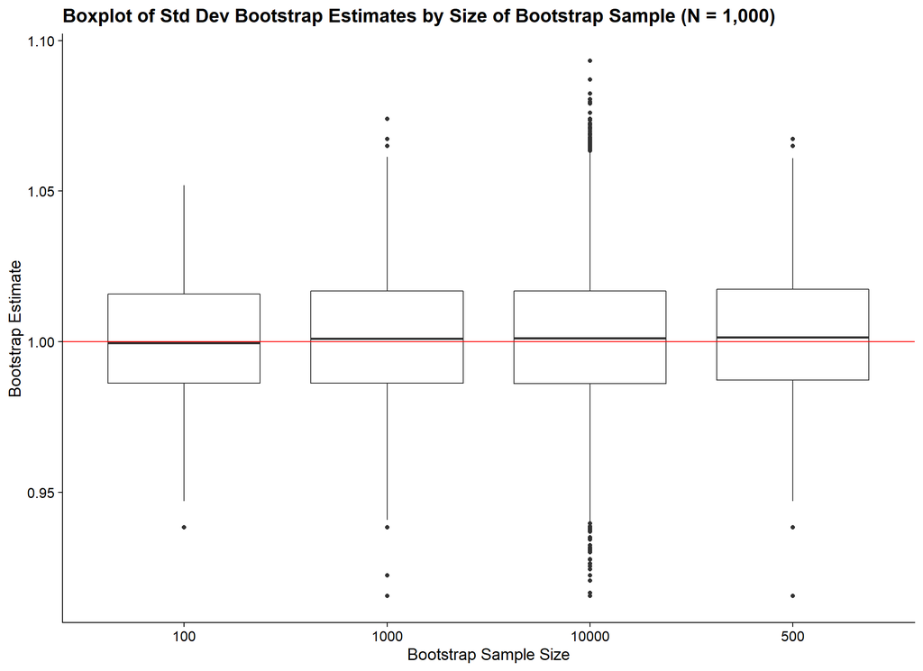

```r
ggplot(boot_1000_sd_tbl) +
  geom_boxplot(aes(x = vec_cast(btstrp_size, character()), y = btstrp_val)) +
  geom_hline(aes(yintercept = 1), colour = 'red') +
  xlab("Bootstrap Sample Size") +
  ylab("Bootstrap Estimate") +
  ggtitle("Boxplot of Std Dev Bootstrap Estimates by Size of Bootstrap Sample (N = 1,000)")
```

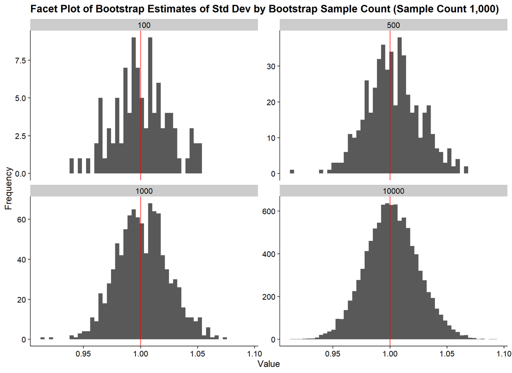

```r
ggplot(boot_1000_sd_tbl) +
  geom_histogram(aes(x = btstrp_val), bins = 50) +
  geom_vline(aes(xintercept = 1), colour = 'red') +
  facet_wrap(vars(btstrp_size), scales = 'free_y') +
  xlab("Value") +
  ylab("Frequency") +
  ggtitle("Facet Plot of Bootstrap Estimates of Std Dev by Bootstrap Sample Count (Sample Count 1,000)")
```

### 1.1.3 Comparison of Data and Bootstrap Estimates

It is important to understand the distinction between the distribution of the original data, and the distribution of the bootstrap estimates. We expect the distribution of bootstrap estimates to have a lower dispersion than that of the original data.

It is worth plotting both these to help up compare them.

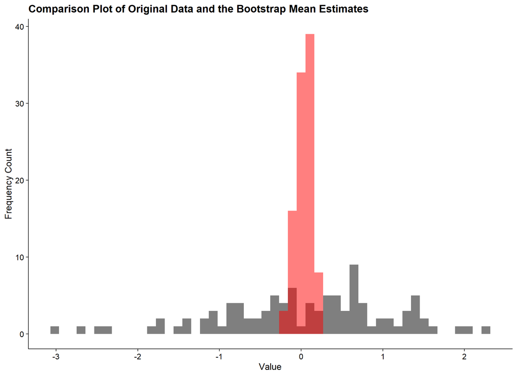

```r
boot_data_tbl <- boot_100_mean_tbl %>% filter(btstrp_size == 100)

ggplot() +
  geom_histogram(aes(x = x), data = F_stdnorm_100_tbl, bins = 50,
                 alpha = 0.5, fill = 'black') +
  geom_histogram(aes(x = btstrp_val), data = boot_data_tbl, bins = 50,
                 alpha = 0.5, fill = 'red') +
  xlab("Value") +
  ylab("Frequency Count") +
  ggtitle("Comparison Plot of Original Data and the Bootstrap Mean Estimates")
```

## 1.2 Count Data: $\lambda = 50$

We now look at count data, such as a Poisson distribution, where the frequency rate of events is larger than 1, say $\lambda = 50$.

```r
F_largecount_tbl <- tibble(x = rpois(10000, lambda = 50))

F_largecount_tbl %>% glimpse()
```

```
## Observations: 10,000
## Variables: 1
## $ x <int> 49, 47, 46, 43, 53, 42, 53, 44, 38, 57, 52, 47, 52, 50, 54, 50, 3...
```

In many cases these counts are well-approximated by using a normal distribution with $\mu = \lambda$ and $\sigma = \sqrt(\lambda)$, but we ignore that for the moment and just bootstrap lambda.

### 1.2.1 Sample Size $N=10$

```r
boot_largecount_10_mean_tbl <- F_largecount_tbl %>%
  head(10) %>%
  pull(x) %>%
  construct_bootstrap_size_plots(mean)

boot_largecount_10_mean_tbl %>%
  group_by(btstrp_size) %>%
  summarise(summ = list(summary(btstrp_val))) %>%
  unnest_wider(summ)
```

```
## # A tibble: 4 x 7
##   btstrp_size  Min. `1st Qu.` Median  Mean `3rd Qu.`  Max.
##         <dbl> <dbl>     <dbl>  <dbl> <dbl>     <dbl> <dbl>
## 1         100  42.5      46.3   47.3  47.4      48.7  51.6
## 2         500  41.8      46.1   47.1  47.2      48.5  52.3
## 3        1000  41.8      46     47.2  47.2      48.4  52.3
## 4       10000  41        46     47.2  47.2      48.4  53.8
```

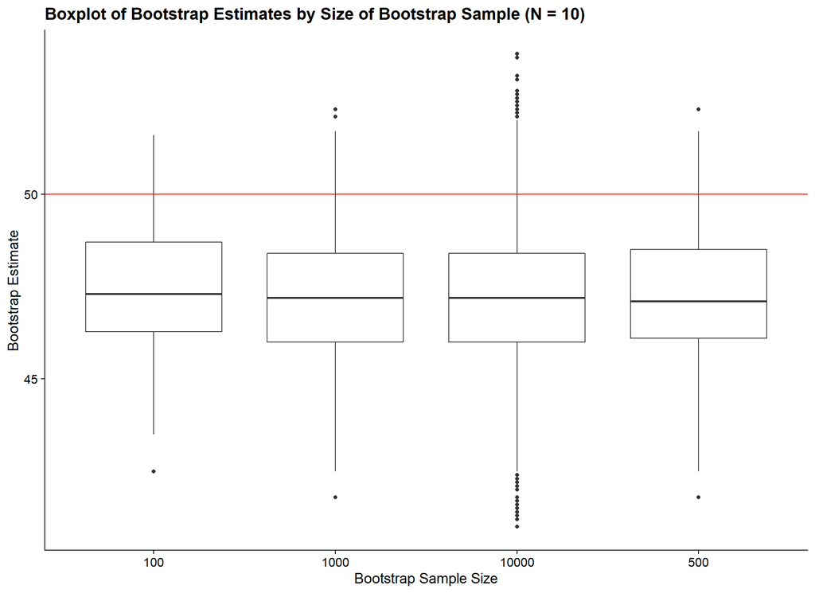

```r
ggplot(boot_largecount_10_mean_tbl) +
  geom_boxplot(aes(x = vec_cast(btstrp_size, character()), y = btstrp_val)) +
  geom_hline(aes(yintercept = 50), colour = 'red') +
  xlab("Bootstrap Sample Size") +
  ylab("Bootstrap Estimate") +
  ggtitle("Boxplot of Bootstrap Estimates by Size of Bootstrap Sample (N = 10)")
```

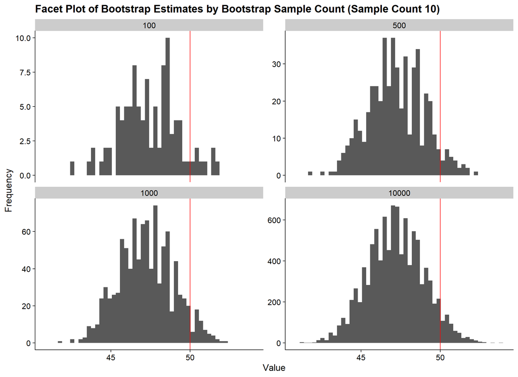

```r
ggplot(boot_largecount_10_mean_tbl) +
  geom_histogram(aes(x = btstrp_val), bins = 50) +
  geom_vline(aes(xintercept = 50), colour = 'red') +
  facet_wrap(vars(btstrp_size), scales = 'free_y') +
  xlab("Value") +
  ylab("Frequency") +
  ggtitle("Facet Plot of Bootstrap Estimates by Bootstrap Sample Count (Sample Count 10)")
```

### 1.2.2 Sample Size $N=100$

```r
boot_largecount_100_mean_tbl <- F_largecount_tbl %>%
  head(100) %>%
  pull(x) %>%
  construct_bootstrap_size_plots(mean)

boot_largecount_100_mean_tbl %>%
  group_by(btstrp_size) %>%
  summarise(summ = list(summary(btstrp_val))) %>%
  unnest_wider(summ)
```

```
## # A tibble: 4 x 7
##   btstrp_size  Min. `1st Qu.` Median  Mean `3rd Qu.`  Max.
##         <dbl> <dbl>     <dbl>  <dbl> <dbl>     <dbl> <dbl>
## 1         100  47.4      48.6   49.0  49.1      49.5  50.6
## 2         500  47.4      48.7   49.1  49.2      49.6  51.1
## 3        1000  47.2      48.7   49.2  49.2      49.6  51.8
## 4       10000  46.5      48.7   49.2  49.2      49.6  51.8
```

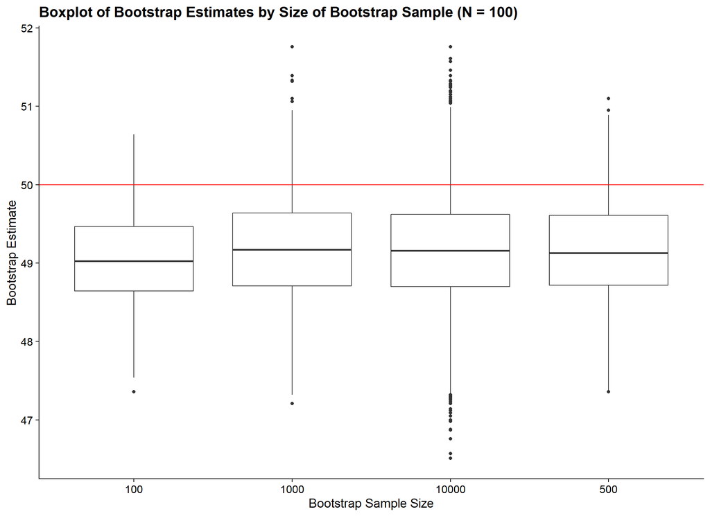

```r
ggplot(boot_largecount_100_mean_tbl) +
  geom_boxplot(aes(x = vec_cast(btstrp_size, character()), y = btstrp_val)) +
  geom_hline(aes(yintercept = 50), colour = 'red') +
  xlab("Bootstrap Sample Size") +
  ylab("Bootstrap Estimate") +
  ggtitle("Boxplot of Bootstrap Estimates by Size of Bootstrap Sample (N = 100)")
```

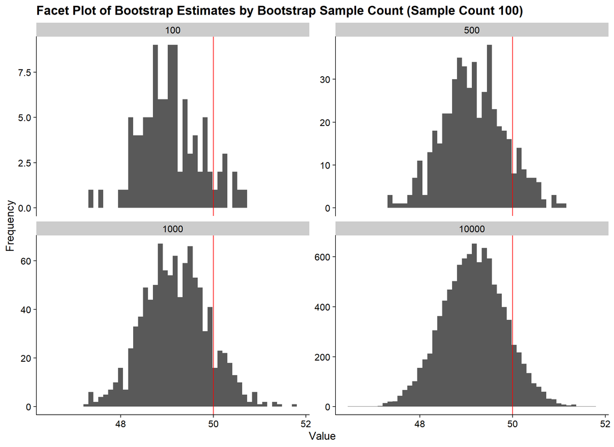

```r
ggplot(boot_largecount_100_mean_tbl) +
  geom_histogram(aes(x = btstrp_val), bins = 50) +
  geom_vline(aes(xintercept = 50), colour = 'red') +
  facet_wrap(vars(btstrp_size), scales = 'free_y') +
  xlab("Value") +
  ylab("Frequency") +
  ggtitle("Facet Plot of Bootstrap Estimates by Bootstrap Sample Count (Sample Count 100)")
```

### 1.2.3 Sample Size $N=1,000$

```r
boot_largecount_1000_mean_tbl <- F_largecount_tbl %>%
  head(1000) %>%
  pull(x) %>%
  construct_bootstrap_size_plots(mean)

boot_largecount_1000_mean_tbl %>%
  group_by(btstrp_size) %>%
  summarise(summ = list(summary(btstrp_val))) %>%
  unnest_wider(summ)
```

```
## # A tibble: 4 x 7
##   btstrp_size  Min. `1st Qu.` Median  Mean `3rd Qu.`  Max.
##         <dbl> <dbl>     <dbl>  <dbl> <dbl>     <dbl> <dbl>
## 1         100  49.5      49.9   50.0  50.0      50.2  50.4
## 2         500  49.4      49.9   50.0  50.0      50.2  50.8
## 3        1000  49.3      49.9   50.0  50.0      50.2  50.8
## 4       10000  49.1      49.9   50.0  50.0      50.2  50.9
```

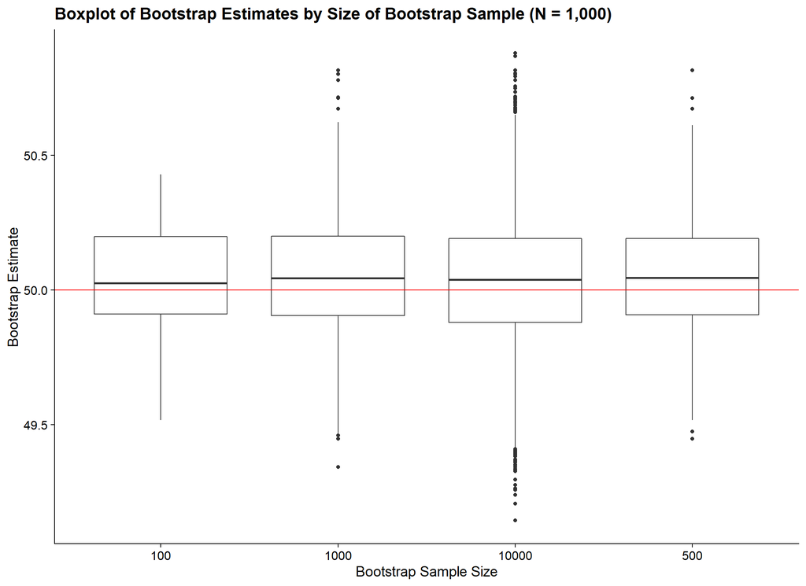

```r
ggplot(boot_largecount_1000_mean_tbl) +
  geom_boxplot(aes(x = vec_cast(btstrp_size, character()), y = btstrp_val)) +
  geom_hline(aes(yintercept = 50), colour = 'red') +
  xlab("Bootstrap Sample Size") +
  ylab("Bootstrap Estimate") +
  ggtitle("Boxplot of Bootstrap Estimates by Size of Bootstrap Sample (N = 1,000)")
```

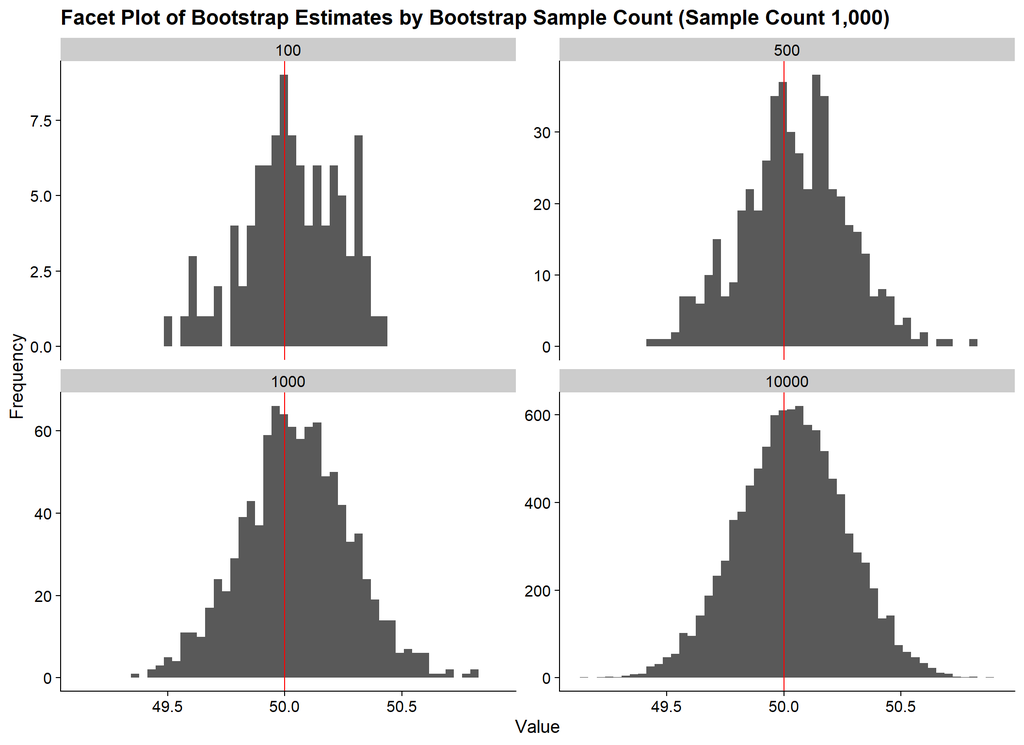

```r
ggplot(boot_largecount_1000_mean_tbl) +
  geom_histogram(aes(x = btstrp_val), bins = 50) +
  geom_vline(aes(xintercept = 50), colour = 'red') +
  facet_wrap(vars(btstrp_size), scales = 'free_y') +
  xlab("Value") +
  ylab("Frequency") +
  ggtitle("Facet Plot of Bootstrap Estimates by Bootstrap Sample Count (Sample Count 1,000)")
```

## 1.3 Count Data: $\lambda = 0.05$

For count data where the count rate is much lower than 1, we end up with small total counts of events. In those cases, we need to think carefully about the size of our data - it is possible we will observe no events at all!

```r
F_smallcount_tbl <- tibble(x = rpois(10000, lambda = 0.05))

F_smallcount_tbl %>% glimpse()
```

```
## Observations: 10,000
## Variables: 1
## $ x <int> 0, 0, 0, 0, 0, 0, 0, 0, 0, 0, 0, 0, 0, 0, 0, 0, 0, 0, 0, 0, 0, 0,...
```

In many cases these counts are well-approximated by using a normal distribution with $\mu = \lambda$ and $\sigma = \sqrt(\lambda)$, but we ignore that for the moment and just bootstrap lambda.

### 1.3.1 Sample Size $N=10$

```r
boot_smallcount_10_mean_tbl <- F_smallcount_tbl %>%
  head(10) %>%
  pull(x) %>%
  construct_bootstrap_size_plots(mean)

boot_smallcount_10_mean_tbl %>%
  group_by(btstrp_size) %>%
  summarise(summ = list(summary(btstrp_val))) %>%
  unnest_wider(summ)
```

```
## # A tibble: 4 x 7
##   btstrp_size  Min. `1st Qu.` Median  Mean `3rd Qu.`  Max.
##         <dbl> <dbl>     <dbl>  <dbl> <dbl>     <dbl> <dbl>
## 1         100     0         0      0     0         0     0
## 2         500     0         0      0     0         0     0
## 3        1000     0         0      0     0         0     0
## 4       10000     0         0      0     0         0     0
```

### 1.3.2 Sample Size $N=100$

```r
boot_smallcount_100_mean_tbl <- F_smallcount_tbl %>%
  head(100) %>%
  pull(x) %>%
  construct_bootstrap_size_plots(mean)

boot_smallcount_100_mean_tbl %>%
  group_by(btstrp_size) %>%
  summarise(summ = list(summary(btstrp_val))) %>%
  unnest_wider(summ)
```

```
## # A tibble: 4 x 7
##   btstrp_size  Min. `1st Qu.` Median   Mean `3rd Qu.`  Max.
##         <dbl> <dbl>     <dbl>  <dbl>  <dbl>     <dbl> <dbl>
## 1         100  0.01      0.03   0.04 0.0403      0.05  0.09
## 2         500  0         0.03   0.04 0.0403      0.05  0.11
## 3        1000  0         0.03   0.04 0.0404      0.05  0.11
## 4       10000  0         0.03   0.04 0.0403      0.05  0.13
```

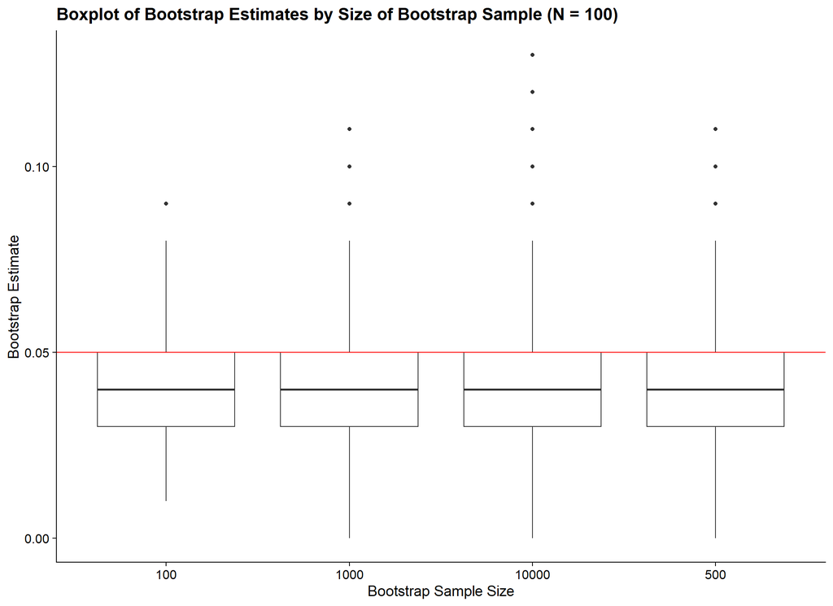

```r
ggplot(boot_smallcount_100_mean_tbl) +
  geom_boxplot(aes(x = vec_cast(btstrp_size, character()), y = btstrp_val)) +
  geom_hline(aes(yintercept = 0.05), colour = 'red') +
  xlab("Bootstrap Sample Size") +
  ylab("Bootstrap Estimate") +
  ggtitle("Boxplot of Bootstrap Estimates by Size of Bootstrap Sample (N = 100)")
```

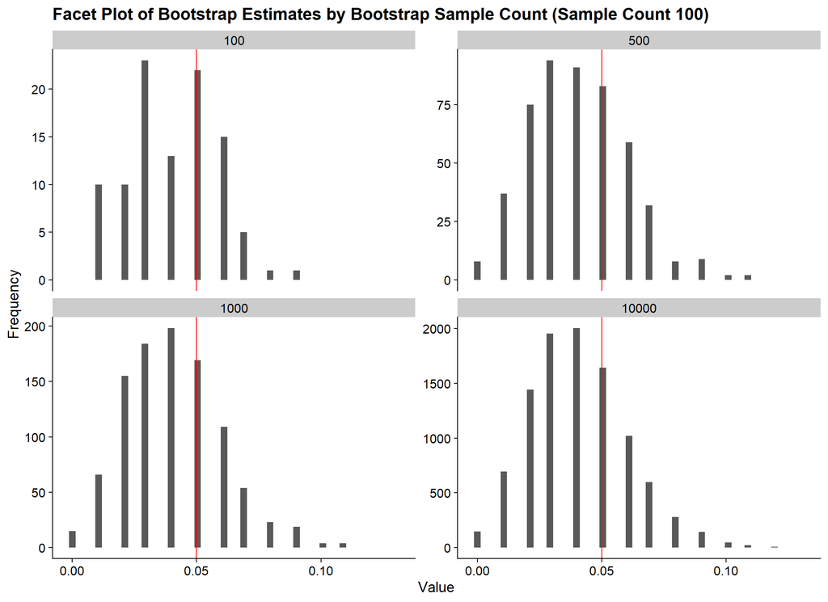

```r
ggplot(boot_smallcount_100_mean_tbl) +
  geom_histogram(aes(x = btstrp_val), bins = 50) +
  geom_vline(aes(xintercept = 0.05), colour = 'red') +
  facet_wrap(vars(btstrp_size), scales = 'free_y') +
  xlab("Value") +
  ylab("Frequency") +
  ggtitle("Facet Plot of Bootstrap Estimates by Bootstrap Sample Count (Sample Count 100)")
```

### 1.3.3 Sample Size $N=1,000$

```r
boot_smallcount_1000_mean_tbl <- F_smallcount_tbl %>%
  head(1000) %>%
  pull(x) %>%
  construct_bootstrap_size_plots(mean)

boot_smallcount_1000_mean_tbl %>%
  group_by(btstrp_size) %>%
  summarise(summ = list(summary(btstrp_val))) %>%
  unnest_wider(summ)
```

```
## # A tibble: 4 x 7
##   btstrp_size  Min. `1st Qu.` Median   Mean `3rd Qu.`  Max.
##         <dbl> <dbl>     <dbl>  <dbl>  <dbl>     <dbl> <dbl>
## 1         100 0.037     0.046 0.052  0.0515     0.056 0.07
## 2         500 0.032     0.046 0.0515 0.0512     0.056 0.072
## 3        1000 0.029     0.046 0.051  0.0511     0.056 0.072
## 4       10000 0.028     0.046 0.051  0.0509     0.055 0.077
```

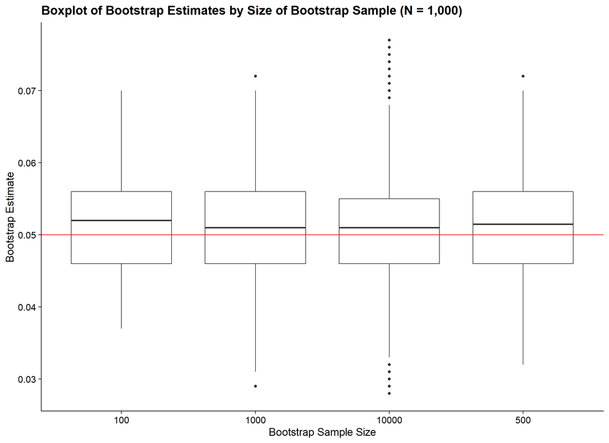

```r
ggplot(boot_smallcount_1000_mean_tbl) +
  geom_boxplot(aes(x = vec_cast(btstrp_size, character()), y = btstrp_val)) +
  geom_hline(aes(yintercept = 0.05), colour = 'red') +
  xlab("Bootstrap Sample Size") +
  ylab("Bootstrap Estimate") +
  ggtitle("Boxplot of Bootstrap Estimates by Size of Bootstrap Sample (N = 1,000)")
```

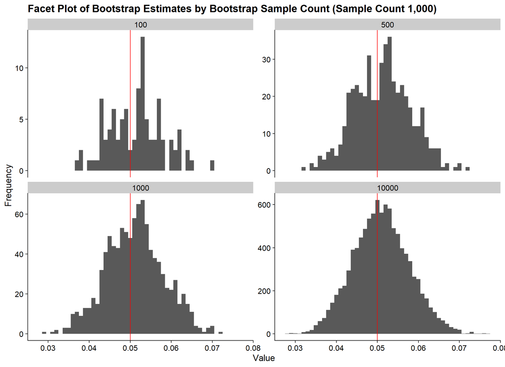

```r
ggplot(boot_smallcount_1000_mean_tbl) +
  geom_histogram(aes(x = btstrp_val), bins = 50) +
  geom_vline(aes(xintercept = 0.05), colour = 'red') +
  facet_wrap(vars(btstrp_size), scales = 'free_y') +
  xlab("Value") +
  ylab("Frequency") +
  ggtitle("Facet Plot of Bootstrap Estimates by Bootstrap Sample Count (Sample Count 1,000)")
```

## 1.4 Pareto Distribution, $\lambda = 1.5$

```r
F_extreme_tbl <- tibble(x = rpareto(100000, location = 1, shape = 1.5))

F_extreme_tbl %>% glimpse()
```

```
## Observations: 100,000
## Variables: 1
## $ x <dbl> 1.07504, 4.36778, 3.29778, 2.91026, 1.77583, 1.43570, 8.17675, 1....
```

### 1.4.1 Sample Size $N=100$

```r
boot_extreme_100_mean_tbl <- F_extreme_tbl %>%
  head(100) %>%
  pull(x) %>%
  construct_bootstrap_size_plots(mean)

boot_extreme_100_mean_tbl %>%
  group_by(btstrp_size) %>%
  summarise(summ = list(summary(btstrp_val))) %>%
  unnest_wider(summ)
```

```
## # A tibble: 4 x 7
##   btstrp_size  Min. `1st Qu.` Median  Mean `3rd Qu.`  Max.
##         <dbl> <dbl>     <dbl>  <dbl> <dbl>     <dbl> <dbl>
## 1         100  2.02      2.36   2.45  2.46      2.54  2.97
## 2         500  2.01      2.33   2.46  2.47      2.59  3.01
## 3        1000  1.89      2.32   2.46  2.47      2.59  3.17
## 4       10000  1.86      2.33   2.46  2.46      2.59  3.42
```

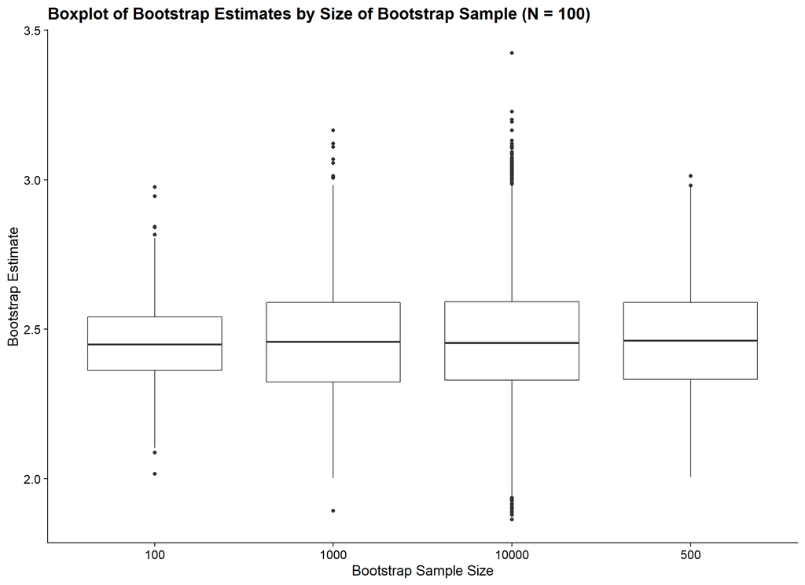

```r
ggplot(boot_extreme_100_mean_tbl) +
  geom_boxplot(aes(x = vec_cast(btstrp_size, character()), y = btstrp_val)) +
  xlab("Bootstrap Sample Size") +
  ylab("Bootstrap Estimate") +
  ggtitle("Boxplot of Bootstrap Estimates by Size of Bootstrap Sample (N = 100)")
```

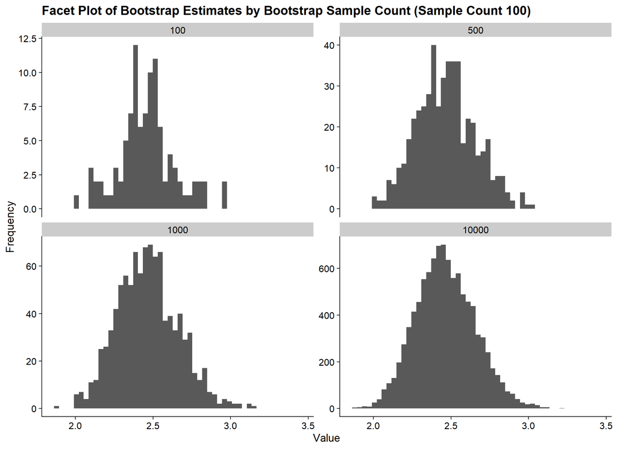

```r
ggplot(boot_extreme_100_mean_tbl) +
  geom_histogram(aes(x = btstrp_val), bins = 50) +
  facet_wrap(vars(btstrp_size), scales = 'free_y') +
  xlab("Value") +
  ylab("Frequency") +
  ggtitle("Facet Plot of Bootstrap Estimates by Bootstrap Sample Count (Sample Count 100)")
```

#### 1.4.1.1 Estimating the Variance

We also want to bootstrap the standard deviation.

```r
boot_extreme_100_sd_tbl <- F_extreme_tbl %>%
  head(100) %>%
  pull(x) %>%
  construct_bootstrap_size_plots(sd)

boot_extreme_100_sd_tbl %>%
  group_by(btstrp_size) %>%
  summarise(summ = list(summary(btstrp_val))) %>%
  unnest_wider(summ)
```

```
## # A tibble: 4 x 7
##   btstrp_size  Min. `1st Qu.` Median  Mean `3rd Qu.`  Max.
##         <dbl> <dbl>     <dbl>  <dbl> <dbl>     <dbl> <dbl>
## 1         100 1.17       1.69   1.91  1.89      2.10  2.53
## 2         500 1.04       1.69   1.89  1.89      2.08  2.66
## 3        1000 1.04       1.69   1.88  1.90      2.10  2.84
## 4       10000 0.823      1.70   1.90  1.90      2.10  3.01
```

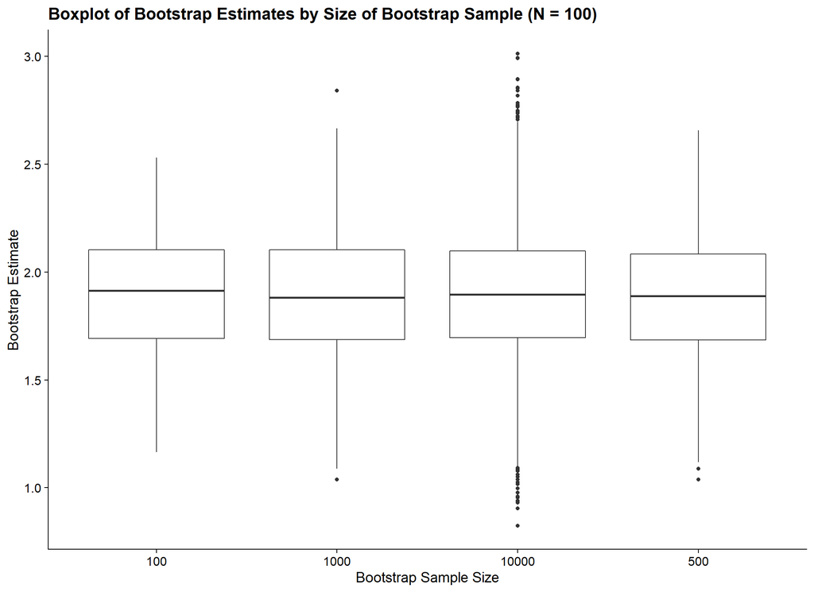

```r
ggplot(boot_extreme_100_sd_tbl) +
  geom_boxplot(aes(x = vec_cast(btstrp_size, character()), y = btstrp_val)) +
  xlab("Bootstrap Sample Size") +
  ylab("Bootstrap Estimate") +
  ggtitle("Boxplot of Bootstrap Estimates by Size of Bootstrap Sample (N = 100)")
```

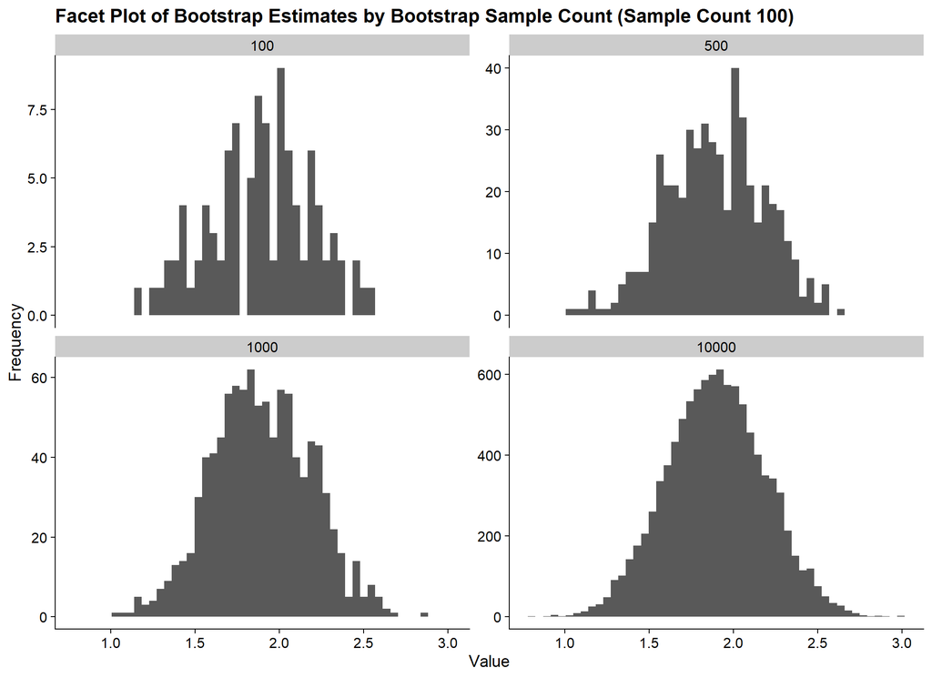

```r
ggplot(boot_extreme_100_sd_tbl) +
  geom_histogram(aes(x = btstrp_val), bins = 50) +
  facet_wrap(vars(btstrp_size), scales = 'free_y') +
  xlab("Value") +
  ylab("Frequency") +
  ggtitle("Facet Plot of Bootstrap Estimates by Bootstrap Sample Count (Sample Count 100)")
```

### 1.4.2 Sample Size $N=1,000$

```r
boot_extreme_1000_mean_tbl <- F_extreme_tbl %>%
  head(1000) %>%
  pull(x) %>%
  construct_bootstrap_size_plots(mean)

boot_extreme_1000_mean_tbl %>%
  group_by(btstrp_size) %>%
  summarise(summ = list(summary(btstrp_val))) %>%
  unnest_wider(summ)
```

```
## # A tibble: 4 x 7
##   btstrp_size  Min. `1st Qu.` Median  Mean `3rd Qu.`  Max.
##         <dbl> <dbl>     <dbl>  <dbl> <dbl>     <dbl> <dbl>
## 1         100  2.35      2.67   2.78  2.78      2.88  3.30
## 2         500  2.33      2.64   2.75  2.76      2.86  3.30
## 3        1000  2.33      2.63   2.74  2.75      2.87  3.30
## 4       10000  2.28      2.64   2.75  2.76      2.86  3.45
```

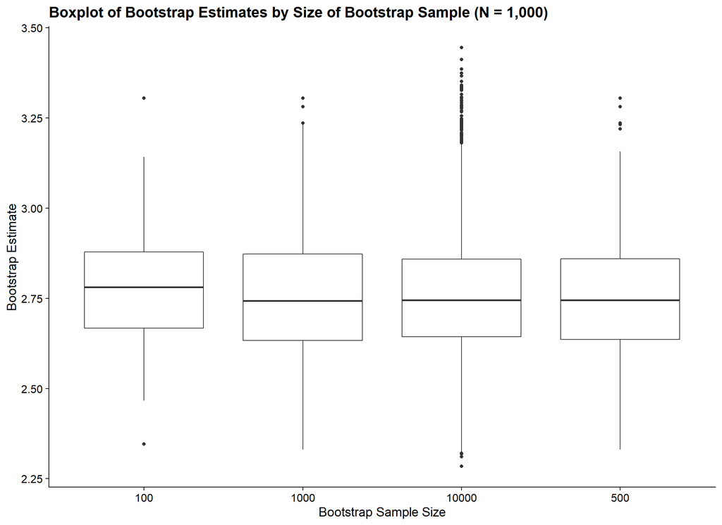

```r
ggplot(boot_extreme_1000_mean_tbl) +
  geom_boxplot(aes(x = vec_cast(btstrp_size, character()), y = btstrp_val)) +
  xlab("Bootstrap Sample Size") +
  ylab("Bootstrap Estimate") +
  ggtitle("Boxplot of Bootstrap Estimates by Size of Bootstrap Sample (N = 1,000)")
```

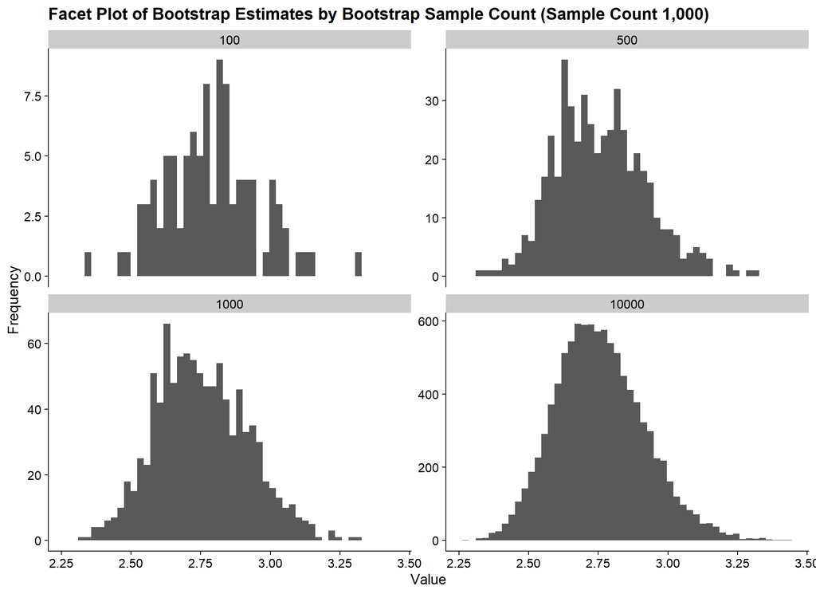

```r
ggplot(boot_extreme_1000_mean_tbl) +
  geom_histogram(aes(x = btstrp_val), bins = 50) +
  facet_wrap(vars(btstrp_size), scales = 'free_y') +
  xlab("Value") +
  ylab("Frequency") +
  ggtitle("Facet Plot of Bootstrap Estimates by Bootstrap Sample Count (Sample Count 1,000)")
```

#### 1.4.2.1 Estimating the Variance

```r
boot_extreme_1000_sd_tbl <- F_extreme_tbl %>%
  head(1000) %>%
  pull(x) %>%
  construct_bootstrap_size_plots(sd)

boot_extreme_1000_sd_tbl %>%
  group_by(btstrp_size) %>%
  summarise(summ = list(summary(btstrp_val))) %>%
  unnest_wider(summ)
```

```
## # A tibble: 4 x 7
##   btstrp_size  Min. `1st Qu.` Median  Mean `3rd Qu.`  Max.
##         <dbl> <dbl>     <dbl>  <dbl> <dbl>     <dbl> <dbl>
## 1         100  3.09      4.31   4.78  4.99      5.72  7.73
## 2         500  2.31      4.32   4.93  4.96      5.65  7.73
## 3        1000  2.29      4.30   4.94  4.94      5.60  7.86
## 4       10000  2.20      4.31   4.97  4.98      5.66  8.60
```

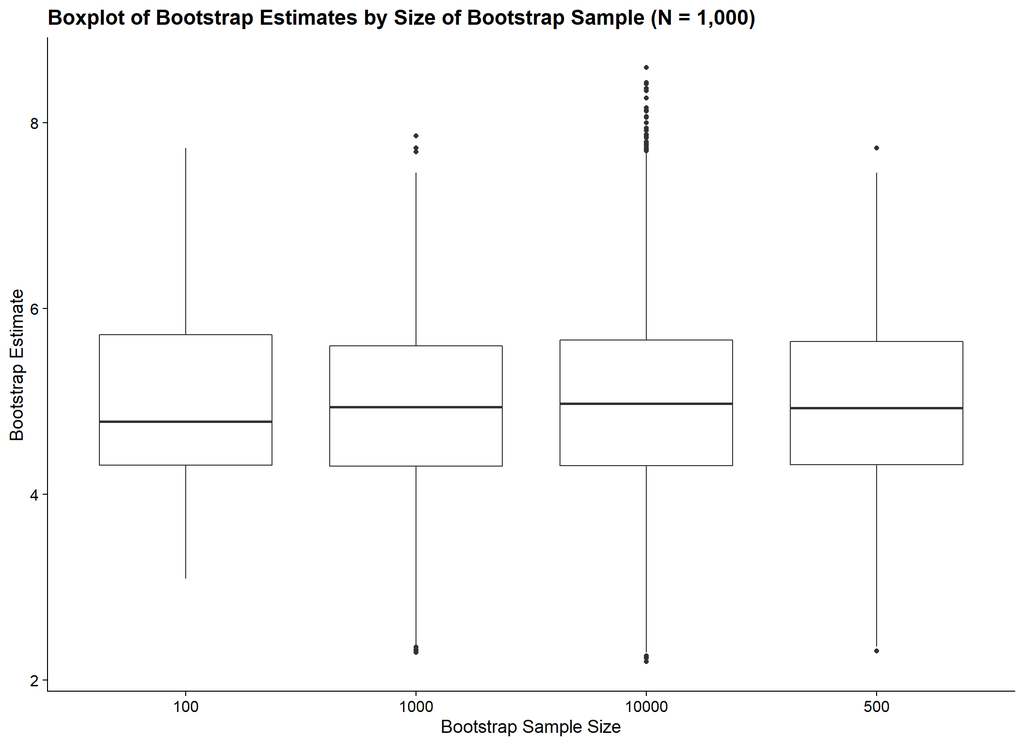

```r
ggplot(boot_extreme_1000_sd_tbl) +
  geom_boxplot(aes(x = vec_cast(btstrp_size, character()), y = btstrp_val)) +
  xlab("Bootstrap Sample Size") +
  ylab("Bootstrap Estimate") +
  ggtitle("Boxplot of Bootstrap Estimates by Size of Bootstrap Sample (N = 1,000)")
```

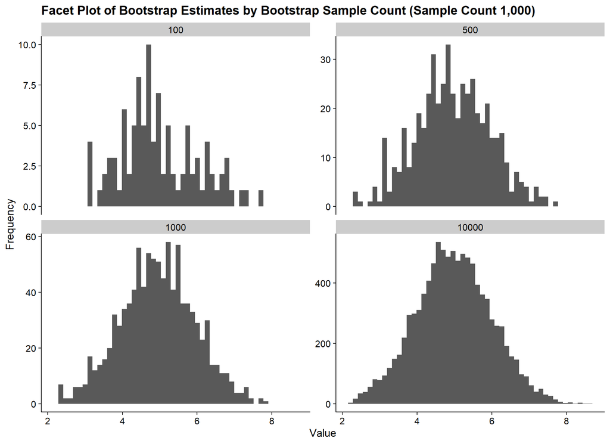

```r
ggplot(boot_extreme_1000_sd_tbl) +
  geom_histogram(aes(x = btstrp_val), bins = 50) +
  facet_wrap(vars(btstrp_size), scales = 'free_y') +
  xlab("Value") +
  ylab("Frequency") +
  ggtitle("Facet Plot of Bootstrap Estimates by Bootstrap Sample Count (Sample Count 1,000)")
```